# Exploration with Nielsen Ad Intel Data

Lun Li

11/7/2018

### Introduction

This report explores the Nielsen Ad Intel Dataset in search of interesting empirical facts.

### 1. Main Figures and Tables

#### 1.1 Total Expenditure on Advertisement, All Industries and Media Types, Annual

Total Expenditure on Advertisement, 10-15

| Year | Expenditure |
| --- | --- |
| 2010 | 91518446109 |
| 2011 | 91423001903 |
| 2012 | 93295111156 |
| 2013 | 95886946996 |
| 2014 | 96887436190 |
| 2015 | 92295676283 |

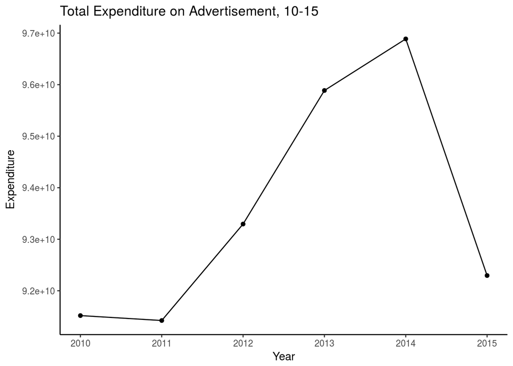

#### 1.2 Total Expenditure on Advertisement, All Industries and Media Types, Monthly

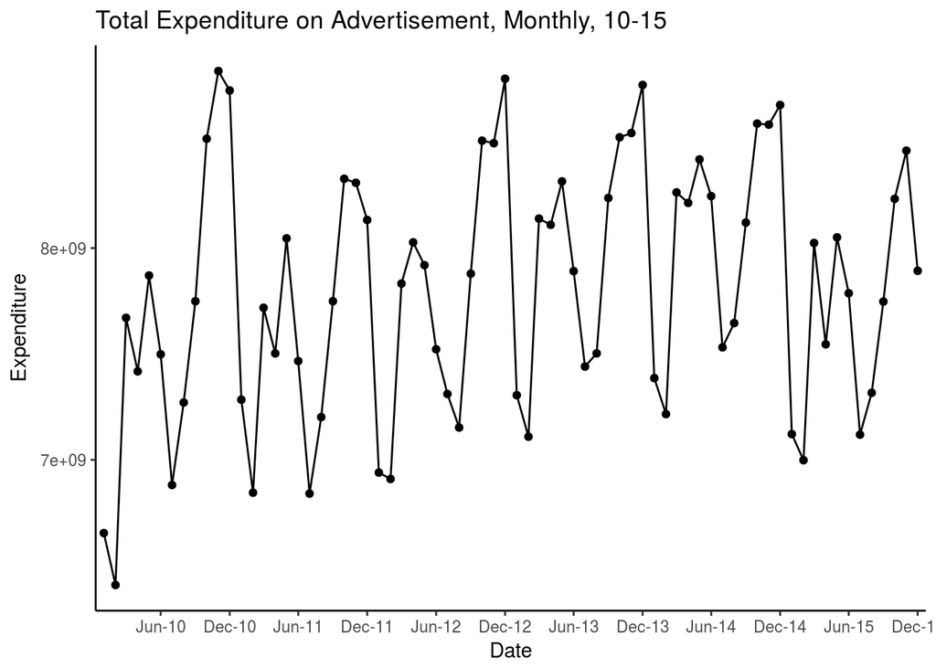

#### 1.3 Composition of Advertisement Expenditure, All Industries, by Major Media Types

An surprising result is that the ad expenditure on internet has gone **down**, not up, from 2010 to 2015. This is true both in dollar values and percentage shares, as is shown below.

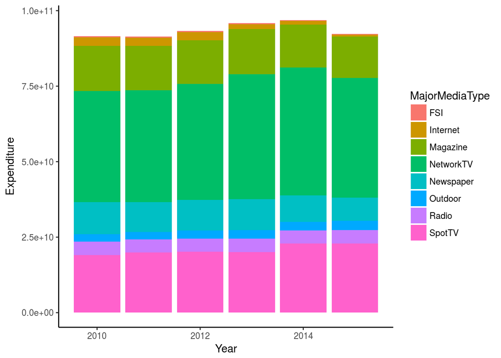

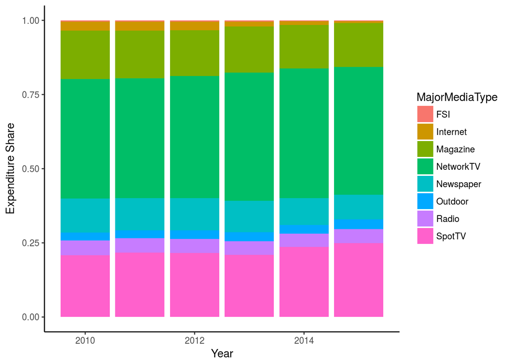

#### 1.4 Total Expenditure on Advertisement, All Industries, by Major Media Type, 10-15, Annual

- Again, surprisingly, the advertisement expenditure on internet has decreased significantly from 2010 to 2015.
- We also see expenditure on TV ads gone up. **This fact is not driven by some “superstar” TV ads (say, during Super Bowl).** I excluded the most expensive and least expensive ads (namely, top 1% and bottom 1%) when constructing these figures.
- You can find a more detailed breakdown by media types in 2.1, where we look at things like “Local Newspaper”, “National Newspaper”, “Local Internet”, “National Internet”, etc.
- Notice that I didn’t include “cinema” ads here because that data is only available from 2013 to 2015. (Let me know if you’d like to see it.)

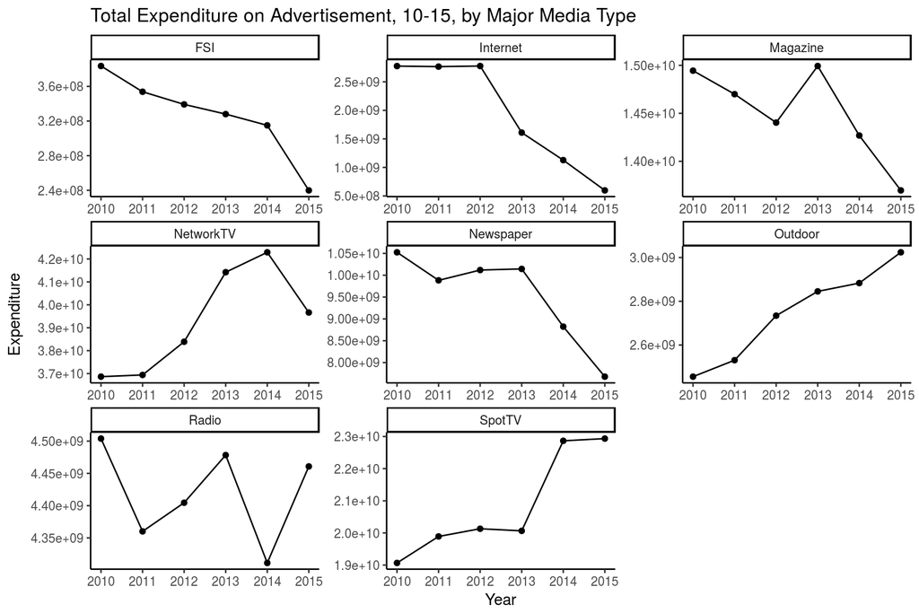

#### 1.5 Total Expenditure on Advertisement All Media Types, by Industry, 10-15, Annual

- You will find an error message below – please ignore it. It has something to do with an industry (“promo”) that only has 1 observation.
- I did not find a detailed description on what the “promo” industry is – I don’t think there’s need to pay much attention to it anyway.
- We see that the ad expenditure of different industries are quite heterogeneous.

```
## geom_path: Each group consists of only one observation. Do you need to
## adjust the group aesthetic?
```

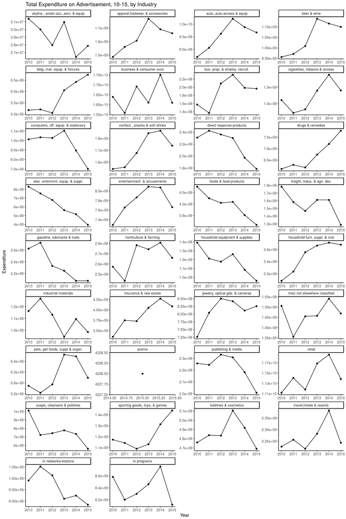

### 2. Other Tables and Figures

Here I keep some additional graphs for your reference. They are usually a more detailed breakdown of a graph that you have seen.

#### 2.1 Total Expenditure on Advertisement, All Industries, by Detailed Media Type, 10-15, Annual

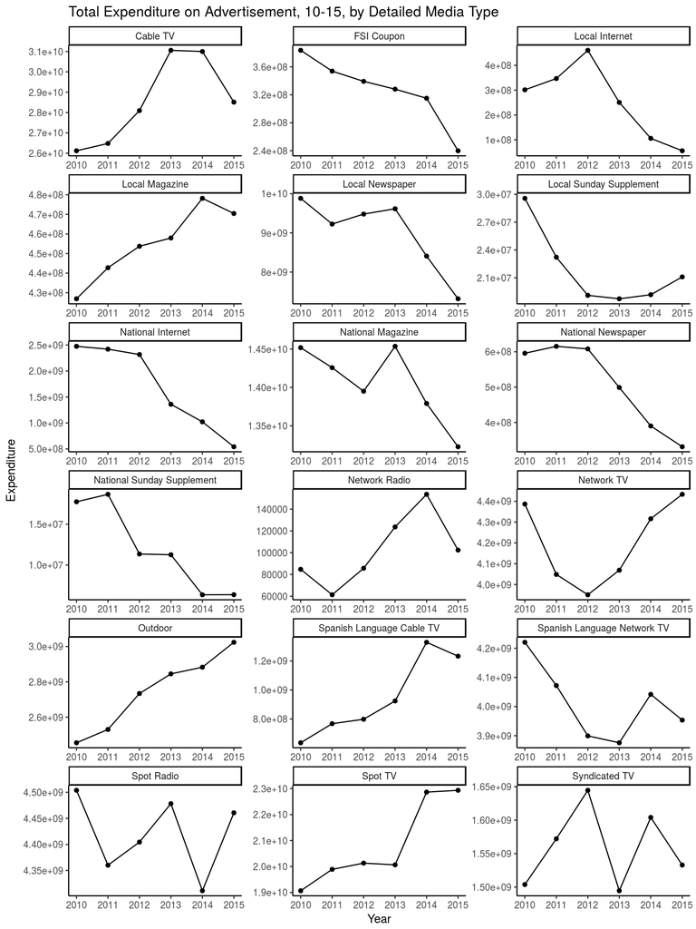

#### 2.2 Total Expenditure on Advertisement, All Industries, by Detailed Media Type, 10-15, Monthly

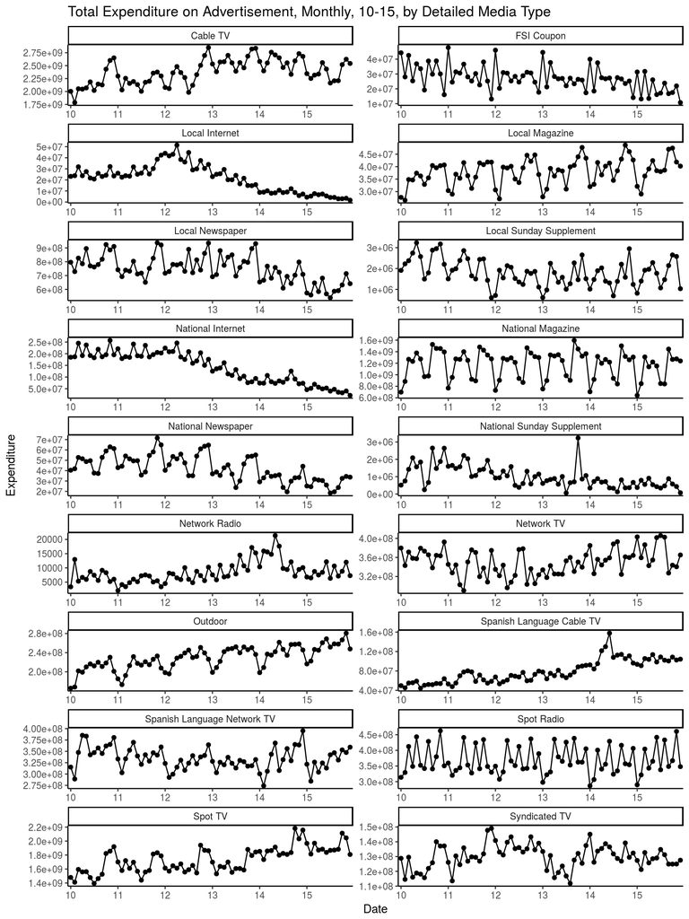

#### 2.3 Total Expenditure on Advertisement, All Media Types, by Industry, 10-15, Monthly

Similar here, you will find an error message below. Please ignore it.

```
## geom_path: Each group consists of only one observation. Do you need to
## adjust the group aesthetic?
```

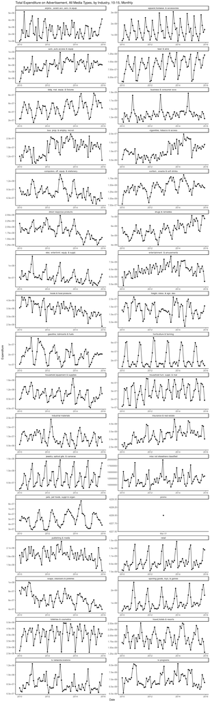

### Next Steps

There are several other plots I’m currently working on. If you’d like to see anything else, please let me know and I’ll add it to the list.

- Ad expenditure by location, both dollar value and growth rate
- Ad expenditure by location and media types
- Ad expenditure by location and industry
- Total number (count) of ads for each year, month, industry and media type
- Total number of **unique** ads for each year, month, industry and media type
- Total number of seconds (i.e. duration) for TV ads and total “size” for newspaper ads
- Total number of people reached, by media type and industry (**only available for National TV, Spot TV, Radio, and Internet. Internet impressions are for age 2+ and could not show breakdown by age, income, etc**)
- Number of people reached per dollar spent, by media type and industry (**only available for National TV, Spot TV, Radio and Internet**)
- Average [GRP](https://digiday.com/marketing/what-is-a-grp-gross-ratings-point/) of advertisements by industry (**only available for National TV, Spot TV, Radio and Internet**. GRP measures the “effectiveness” of an ad)
- Average Cost Per Point (= Expenditures / GRP) of advertisement, by industry (**only available for National TV, Spot TV, Radio and Internet**)